# Lab2B_nch

Nathan Haywood

1/29/2020

### Exercise 1: Add, subtract, multipy and divide the following two vectors (1,3,6,9,12) and (1,0,1,0,1)

```r
v1 <- c(1,3,6,9,12)
v2 <- c(1,0,1,0,1)

sum = v1+v2
diff = v1-v2
prod = v1*v2
quot = v1/v2
```

### Exercise 2: Create 3 different vectors from (0,1,2,3), (“aa”,“bb”,“cc”,“dd”) and (“aa”,1,“bb”,2). Use str() to determine what data types each vector holds.

```r
temp1 <- c(0,1,2,3)
temp2 <- c("aa", "bb", "cc", "dd")
temp3 <- c("aa", 1, "bb", 2)

str(temp1)
```

```
##  num [1:4] 0 1 2 3
```

```r
str(temp2)
```

```
##  chr [1:4] "aa" "bb" "cc" "dd"
```

```r
str(temp3)
```

```
##  chr [1:4] "aa" "1" "bb" "2"
```

### Exercise 3: Create a matrix of the data: genotype 1 (“AA”, “AA”, “AG”, “GG”, “GG”), genotype 2 (“AA”, “AA”, “GG”, “GG”, “GG”). Display the matrix. Use the table function (as in the above examples) to show the total number of each genotype.

```r
genotype1 <- c("AA", "AA", "AG", "GG", "GG")
genotype2 <- c("AA", "AA", "GG", "GG", "GG")
matr <- rbind(genotype1, genotype2)
matr
```

```
##           [,1] [,2] [,3] [,4] [,5]
## genotype1 "AA" "AA" "AG" "GG" "GG"
## genotype2 "AA" "AA" "GG" "GG" "GG"
```

```r
table(matr)
```

```
## matr
## AA AG GG
##  4  1  5
```

### Exercise 4: Create a dataframe of the following experiment in samples were collected every 2 minutes starting at t = 0. treatment 1 (0,1,2,3,4), treatment 2 (0,2,4,6,8), treatment 3 (0,3,6,9,12). Display the dataframe. Plot treatment 3 vs. time (you will need to load time as a column rather than a row name)

```r
Time <- c(0,2,4,6,8)
Treatment1 <- c(0,1,2,3,4)
Treatment2 <- c(0,2,4,6,8)
Treatment3 <- c(0,3,6,9,12)
df = data.frame(Treatment1, Treatment2, Treatment3, row.names = Time)
df
```

```
##   Treatment1 Treatment2 Treatment3
## 0          0          0          0
## 2          1          2          3
## 4          2          4          6
## 6          3          6          9
## 8          4          8         12
```

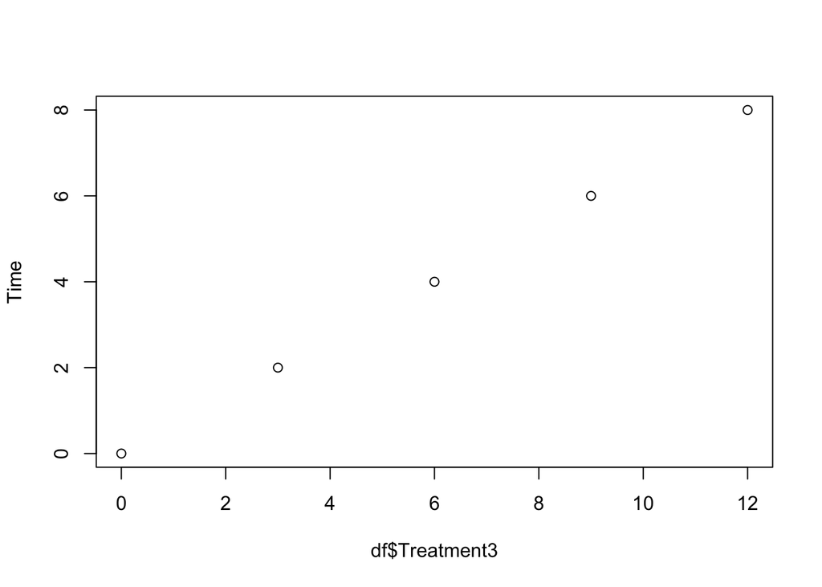

```r
plot(df$Treatment3, Time)
```

### Exercise 5: Following the example above with the truncated file use read.table to import the full SNP file 23andME_complete.txt. (This is a large file and may take several minutes to load into R)What object type is chromosome? Why is it different from the above SNP_table example with the truncated file?

```r
table1 <- read.table("23andMe_complete.txt", header = TRUE, sep = "\t", row.names = 1)
str(table1)
```

```
## 'data.frame':    960614 obs. of  3 variables:
##  $ chromosome: Factor w/ 25 levels "1","10","11",..: 1 1 1 1 1 1 1 1 1 1 ...
##  $ position  : int  82154 752566 752721 776546 798959 800007 838555 846808 854250 861808 ...
##  $ genotype  : Factor w/ 20 levels "--","A","AA",..: 3 3 15 5 5 8 4 10 5 15 ...
```

```r
table2 <- read.table("23andMe_example_cat25.txt", header = TRUE, sep = "\t", row.names = 1)
str(table2)
```

```
## 'data.frame':    10 obs. of  3 variables:
##  $ chromosome: int  1 1 1 1 1 1 1 1 1 1
##  $ position  : int  82154 752566 752721 776546 798959 800007 838555 846808 854250 861808
##  $ genotype  : Factor w/ 6 levels "AA","AC","AG",..: 1 1 6 3 3 4 2 5 3 6
```

### Exercise 6: Make a table with the total number of each genotype. There may be unsual genotypes. 23andMe reports a very small number of deletions and insertions coded as D DD DI I II. The double dash – represents an uncertain (not reported) call at this position.

```r
table(table1$genotype)
```

```
##
##     --      A     AA     AC     AG     AT      C     CC     CG     CT      D
##  21109   6676 147157  25036 109001    569   7188 173264   1003 108992     36
##     DD     DI      G     GG     GT      I     II      T     TT
##    157     17   7061 173054  24727    113    685   6643 148126
```

### Exercise 7: Determine which chromosome(s) the single letter genotype A is found on (e.g which chromosomes have only one copy of DNA)? Hint: Use subset() to make a table with just the genotype A.

```r
Genotype_A <- subset(table1, genotype == 'A')
```